## Simulation of responses to selection with changes in recombination rate and landscape.

#### Susan E. Johnston, 2015-11-23 20:18:27

### Introduction.

Meiotic recombination is a fundamental feature of sexual reproduction and is an important source of genetic diversity. It can uncouple beneficial alleles from linked deleterious ones, creating new combinations of alleles that can allow populations to respond faster to selection. On the other hand, recombination can increase mutations at crossover sites, and can break up favourable combinations of alleles previously built up by selection. Recombination rate is likely to have a fairly simple genetic architecture, with a handful of loci with relatively large effects on rate variation, such as the *RNF212*/*CPLX1* region in humans, cattle and sheep.

The majority of cross-overs occur in regions known as “hotspots”  short stretches of DNA 1-2kb long. In some mammal species (e.g. humans, mice) the location of hotspots can change rapidly, often attributed to variation in the gene *PRDM9*; in others (e.g. dogs), *PRDM9* has lost its function leading to stable recombination hotspots over longer periods of time. However, there remains little understanding of how recombination landscapes vary in non-model species, and if rapid hotspot turnover could be favoured if selection is strong (e.g. in domesticated species).

The following is a simulation study that investigates how responses to selection change when recombination landscape remains stable, incomparison to when it changes due to the action of a single polymorphic modifier locus, such as *PRDM9*.

### Model

The function `simPopulationResponse` simulates a population with recombination and a polygenic phenotype that is under selection.

The phenotype is controlled by `n.loci` with two alleles, `0` and `1`, with the latter contributing `+1` unit to phenotype (the former contributing nothing to phenotype). Genotypes `00`, `01` and `11` contribute `0`, `1` and `2` units to phenotype respectively. The loci have allele frequencies `allele.freqs`, which indicates the frequency of the `0` allele.

To simulate recombination, a map of recombination fractions is provided to the function as a vector. However, as recombination rates and landscapes can be oligogenic (see above), the function can also accommodate a modifier locus that results in different recombination maps for each genotype at the modifier locus. For example, for a locus that additively increases recombination rate based on modifier genotypes AA, AB and BB, then maps for a three locus model could be as follows:

```r
map <- list(
  c(0.1, 0.1),    # Map for genotype AA; used if freq = 0
  c(0.15, 0.15),  # Map for genotype AB
  c(0.2, 0.2)     # Map for genotype BB
  )
```

In this case, three maps are provided to the function is a `list()`. The frequency of the modifier locus is specified as `modifier.found.freq`. If the modifier frequency is 0, then only one map needs to be provided, but must still be passed as a `list()` object.

`n.found.hap` haplotypes are generated to form a pool for the founder population by sampling alleles at random along the chromosome, with the probability of their allele frequency.

A founder population is generated of size `n.m` males and `n.f` females. Each individual in the founder population has two haplotypes sampled at random from the haplotype pool. Genotypes at the modifier loci are also assigned to founder individuals independently of haplotypes (i.e. unlinked) to the founder population. Genotypes are sampled based on probabilities from the allele frequency `modifier.found.freq` and assuming Hardy Weinberg Equilibrium.

In the founder population, individuals that breed and contribute to the next generation are determined based on the selection thresholds for males `sel.thresh.m` and females `sel.thesh.m`. This is done by sorting the phenotypes in each sex and selecting the top proportion of individuals based on specified parameters.

Once breeding individuals are determined, then the breeding structure can be sampled. Each female has `f.RS` offspring, with sexes either assigned at random (`force.equal.sex = FALSE`) or assigned to ensure a defined number of male or female offspring in that generation (`force.equal.sex = T`). Males are sampled either at random from breeding individuals (`force.equal.male.success` = F) or are sampled as equally as possible (`force.equal.male.success = T`).

When offspring have been determined, the gametes transmitted from the parents to the offspring have to be generated. For each haplotype that the parent has, crossover positions for recombination are sampled based on the recombination fractions between loci for it’s genotype at the modifier locus. Once these are determined, one haplotype is sampled from the two recombinant haplotypes and is assigned as a haplotype in the offspring. A unique meiosis is carried out for each offspring. Each offspring will also receive an allele for the modifier locus from each parent, sampled at random.

This creates the new breeding population, and the process is repeated for `n.generations`.

For models comparing outcomes between allele frequencies at modifier loci, a founder population can be simulated using the function `createFounderObject`; for example, if assigned to object `founder1`, then the founder object can be provided to the `simPopulationResponse` function with the argument `FounderObject = founder1`. This will provide the same founder population to multiple functions.

##### What does the function *not* accommodate, but can and should be added in the future?

- At present I assume equal recombination rates in each sex.
- Modifier loci for recombination rate e.g. *RNF212*/*CLPX1* may have sex specific or sexually antagonistic effects.
- Only one modifier can be modelled at present.
- Population sizes are constant; if `force.equal.sex = F`, then the population size can vary naturally, which can result in extinctions or very large increases in population size. At present simulations can be rerun on extinction by wrapping the `simPopulationResponse` function in `restartOnExtinct()` although this may not be recommended if extinction is meaningful!
- Crossover-interference is not modelled - recombination at one position does not affect the probability of recombination at adjascent loci.
- Mutation is not modelled.
- Costs of decreased genetic variability…
- Selection on other polygenic phenotypes - i.e. contribution of loci to different phenotypes? Or selecting which loci have effects on phenotype (interlaced?)
- Selection in males only
- Offspring survival probabilities
- At present generations are discrete (non-overlapping) and there is no immigration.

### 1. Simple response to selection model (No modifier)

Specify model parameters:

```r
n.females         <- 50  # Number of females in the founder generation
n.males           <- 50  # Number of males in the founder generation
n.offspring       <- 2   # Number of offspring per female
male.sel.thresh   <- 0.4 # Top proportion of males that will be selected
female.sel.thresh <- 1   # Top proportion of females that will be selected
generations       <- 100 # Number of generations to run the simulation.

n.loci <- 100      # The number of loci contributing to the trait
n.found.hap <- 100 # Number of founder haplotypes
```

I will start with a simple model of recombination on a chromosome that is 1 Morgan long (i.e. an average of one crossover per meiosis) with equal recombination probabilities between loci. If we have 100 loci then we have a mean recombination fraction between loci of 0.01. Let’s also specify equal allele frequencies at each locus (i.e. 0.5).

```r
map.1  <- rep(1/n.loci, n.loci)
freq.1 <- rep(0.5, n.loci)
```

Run the function:

```r
sim.1 <- simPopulationResponse(n.found.hap = n.found.hap,
                               n.loci = n.loci,
                               n.f = n.females, n.m = n.males,
                               map.list = list(map.1),
                               allele.freqs = freq.1,
                               f.RS = n.offspring,
                               sel.thresh.f = female.sel.thresh,
                               sel.thresh.m = male.sel.thresh,
                               modifier.found.freq = 0,
                               n.generations = generations,
                               force.equal.male.success = T,
                               force.equal.sex = T,
                               progressBar = F)
```

The `sim.1` object contains the slot `results`, which is a list of data frames containing information on each simulated individual in each generation. Headers indicate the generation, ID, mother and father IDs from the previous generation, sex (1 = male, 2 = female), the phenotypic value, the genotype of the individual for a modifier locus (this will be specified later) and whether or not that individual reproduced:

```r
# example from generation two

head(sim.1$results[[3]])
```

```
##   GEN ID MOTHER FATHER SEX PHENO modifier Bred
## 1   2  1      2     31   1    88        1    0
## 2   2  2      2     77   2    97        1    1
## 3   2  3      4     29   1   108        1    1
## 4   2  4      4     75   2    91        1    1
## 5   2  5      6     11   1   106        1    0
## 6   2  6      6     69   2   116        1    1
```

The list can be condensed into a `data.table`. Let’s examine what happens over the course of the simulation:

```r
sim.1.res <- rbindlist(sim.1$results)

sim.1.res
```

```
##        GEN  ID MOTHER FATHER SEX PHENO modifier Bred
##     1:   0   1     NA     NA   1    98        1    0
##     2:   0   2     NA     NA   1    94        1    0
##     3:   0   3     NA     NA   1    92        1    0
##     4:   0   4     NA     NA   1    97        1    0
##     5:   0   5     NA     NA   1   106        1    1
##    ---
## 10096: 100  96     96     63   2   196        1    1
## 10097: 100  97     98     11   1   196        1    1
## 10098: 100  98     98     77   2   196        1    1
## 10099: 100  99    100     13   1   196        1    1
## 10100: 100 100    100     65   2   196        1    1
```

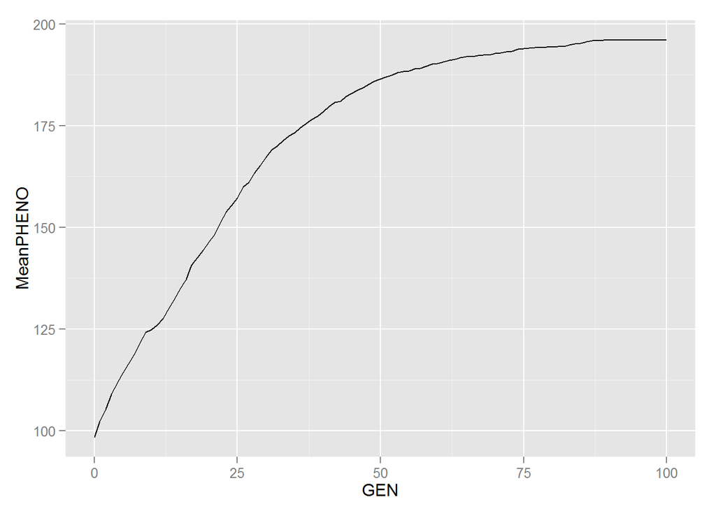

```r
df1 <- ddply(sim.1.res, .(GEN), summarise, MeanPHENO = mean(PHENO))
ggplot(df1, aes(GEN, MeanPHENO)) + geom_line()
```

*NB. One hypothesis to explain why recombination can be deleterious is that it can break up beneficial combinations of alleles that have already been built up by selection over time - but when selection is strong and directional, this not the case (although all variance in phenotype has disappeared).*

### 2. Modifier increasing recombination rates.

What happens to the response to selection if recombination rates are increased? Let’s try a chromosome of 2 Morgans in length, but with the same number of loci.

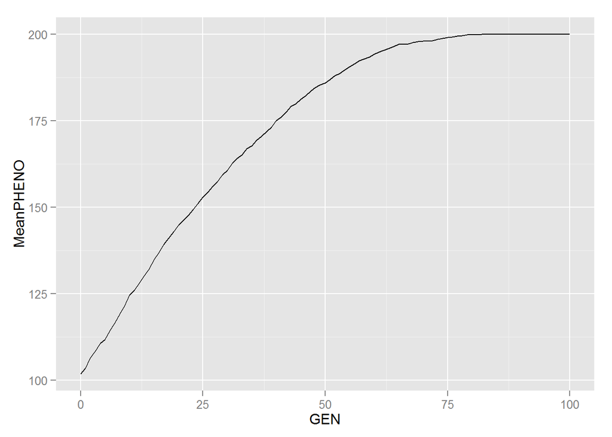

```r
map.2  <- rep(2/n.loci, n.loci)
freq.2 <- rep(0.5, n.loci)
```

In this case, the response to selection is faster, reaching a maximum value of 200 at generation 84

I will now run each of these models for several iterations, comparing the outcome of models where the map is 1M and 2M. These models will be run specifying the `createFounderObject` output so that on the same iteration, the same founder population will be used with both maps.

```r
#~~ Specify number of iterations

n.iterations <- 10
```

Run simulations (code not shown):

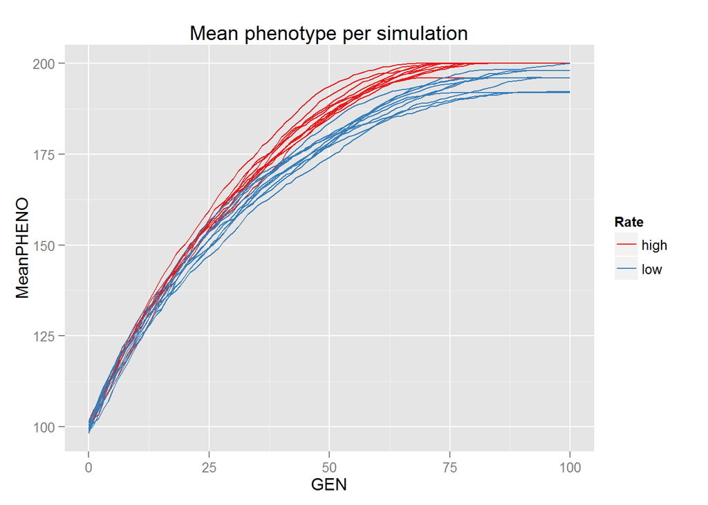

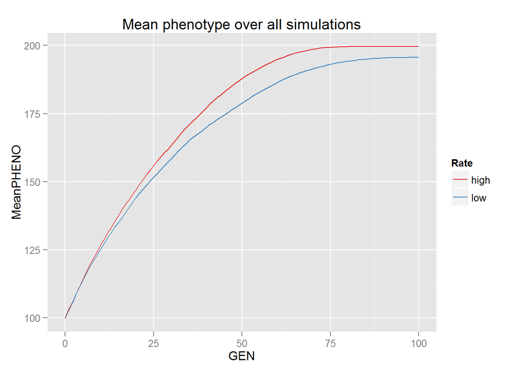

From above, it appears that higher recombination rates allows the population to respond to selection faster.

### 3. Modifier locus that increases recombination rate.

Above, the two simulations were carried out in populations with fixed rates. Here, I will simulate a modifier that has an additive effect on recombination rate, doubling the rate between the two homozygotes, at a frequency of 0.5:

```r
map.3 <- list(rep(1  /n.loci, n.loci),
              rep(1.5/n.loci, n.loci),
              rep(2  /n.loci, n.loci))
```

Now each iteration will run with a modifier frequency of 0 and of 0.5 with the same founder population per iteration.

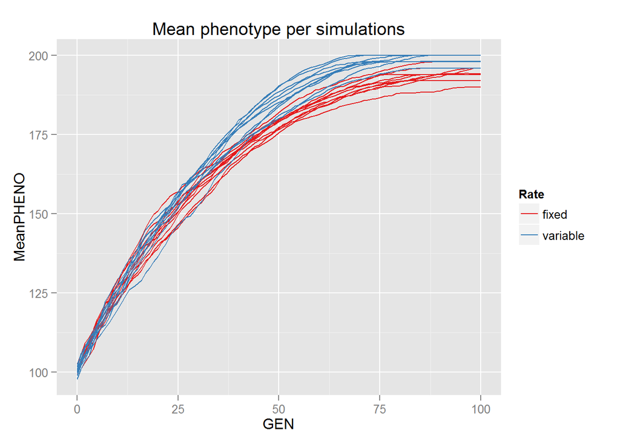

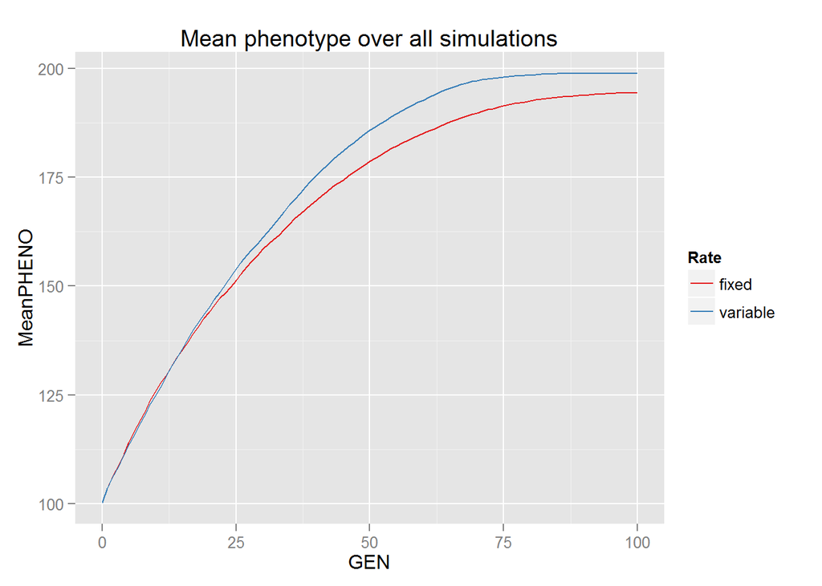

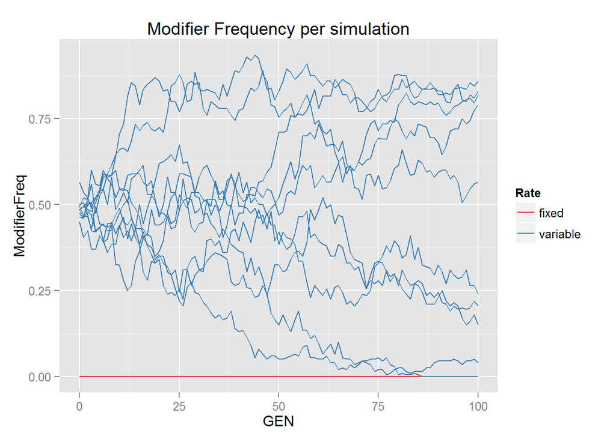

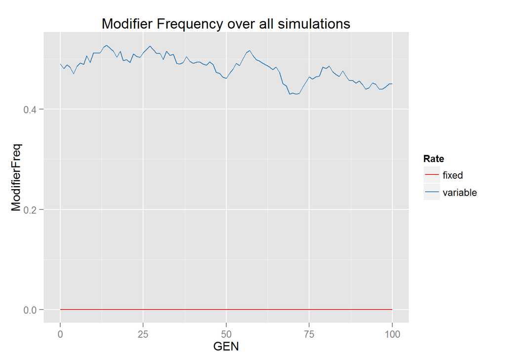

### 3. Modifier that changes location of recombination

I will now specify a modifier locus that results in maps with variation in recombination landscape - i.e. changing the probability that recombination will occur within particular regions.

```r
map.4 <- list(rep(c(0, 2/n.loci), length.out = n.loci),
              rep(1/n.loci, n.loci),
              rep(c(2/n.loci, 0), length.out = n.loci))

map.4
```

```
## [[1]]
##   [1] 0.00 0.02 0.00 0.02 0.00 0.02 0.00 0.02 0.00 0.02 0.00 0.02 0.00 0.02
##  [15] 0.00 0.02 0.00 0.02 0.00 0.02 0.00 0.02 0.00 0.02 0.00 0.02 0.00 0.02
##  [29] 0.00 0.02 0.00 0.02 0.00 0.02 0.00 0.02 0.00 0.02 0.00 0.02 0.00 0.02
##  [43] 0.00 0.02 0.00 0.02 0.00 0.02 0.00 0.02 0.00 0.02 0.00 0.02 0.00 0.02
##  [57] 0.00 0.02 0.00 0.02 0.00 0.02 0.00 0.02 0.00 0.02 0.00 0.02 0.00 0.02
##  [71] 0.00 0.02 0.00 0.02 0.00 0.02 0.00 0.02 0.00 0.02 0.00 0.02 0.00 0.02
##  [85] 0.00 0.02 0.00 0.02 0.00 0.02 0.00 0.02 0.00 0.02 0.00 0.02 0.00 0.02
##  [99] 0.00 0.02
##
## [[2]]
##   [1] 0.01 0.01 0.01 0.01 0.01 0.01 0.01 0.01 0.01 0.01 0.01 0.01 0.01 0.01
##  [15] 0.01 0.01 0.01 0.01 0.01 0.01 0.01 0.01 0.01 0.01 0.01 0.01 0.01 0.01
##  [29] 0.01 0.01 0.01 0.01 0.01 0.01 0.01 0.01 0.01 0.01 0.01 0.01 0.01 0.01
##  [43] 0.01 0.01 0.01 0.01 0.01 0.01 0.01 0.01 0.01 0.01 0.01 0.01 0.01 0.01
##  [57] 0.01 0.01 0.01 0.01 0.01 0.01 0.01 0.01 0.01 0.01 0.01 0.01 0.01 0.01
##  [71] 0.01 0.01 0.01 0.01 0.01 0.01 0.01 0.01 0.01 0.01 0.01 0.01 0.01 0.01
##  [85] 0.01 0.01 0.01 0.01 0.01 0.01 0.01 0.01 0.01 0.01 0.01 0.01 0.01 0.01
##  [99] 0.01 0.01
##
## [[3]]
##   [1] 0.02 0.00 0.02 0.00 0.02 0.00 0.02 0.00 0.02 0.00 0.02 0.00 0.02 0.00
##  [15] 0.02 0.00 0.02 0.00 0.02 0.00 0.02 0.00 0.02 0.00 0.02 0.00 0.02 0.00
##  [29] 0.02 0.00 0.02 0.00 0.02 0.00 0.02 0.00 0.02 0.00 0.02 0.00 0.02 0.00
##  [43] 0.02 0.00 0.02 0.00 0.02 0.00 0.02 0.00 0.02 0.00 0.02 0.00 0.02 0.00
##  [57] 0.02 0.00 0.02 0.00 0.02 0.00 0.02 0.00 0.02 0.00 0.02 0.00 0.02 0.00
##  [71] 0.02 0.00 0.02 0.00 0.02 0.00 0.02 0.00 0.02 0.00 0.02 0.00 0.02 0.00
##  [85] 0.02 0.00 0.02 0.00 0.02 0.00 0.02 0.00 0.02 0.00 0.02 0.00 0.02 0.00
##  [99] 0.02 0.00
```

```r
#~~ Specify number of iterations

generations <- 200
n.iterations <- 20
```

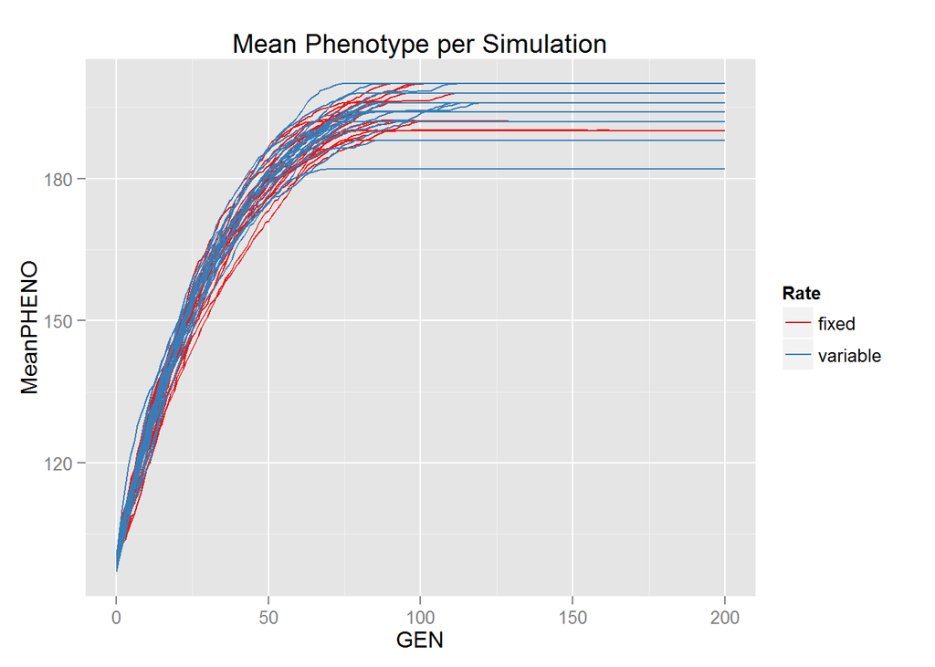

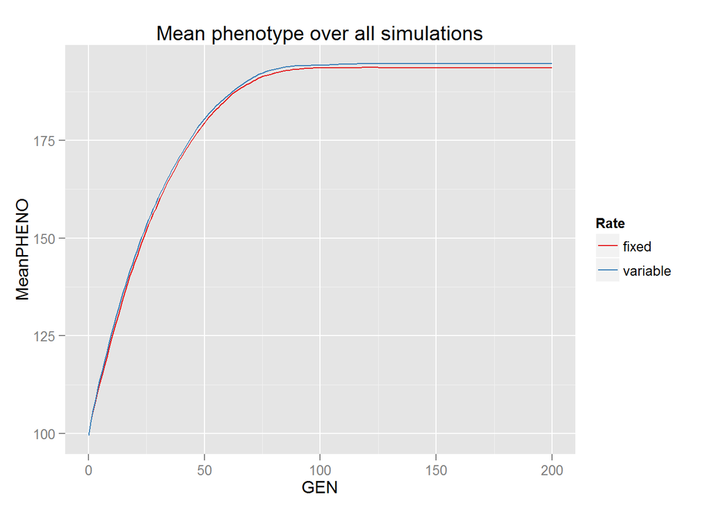

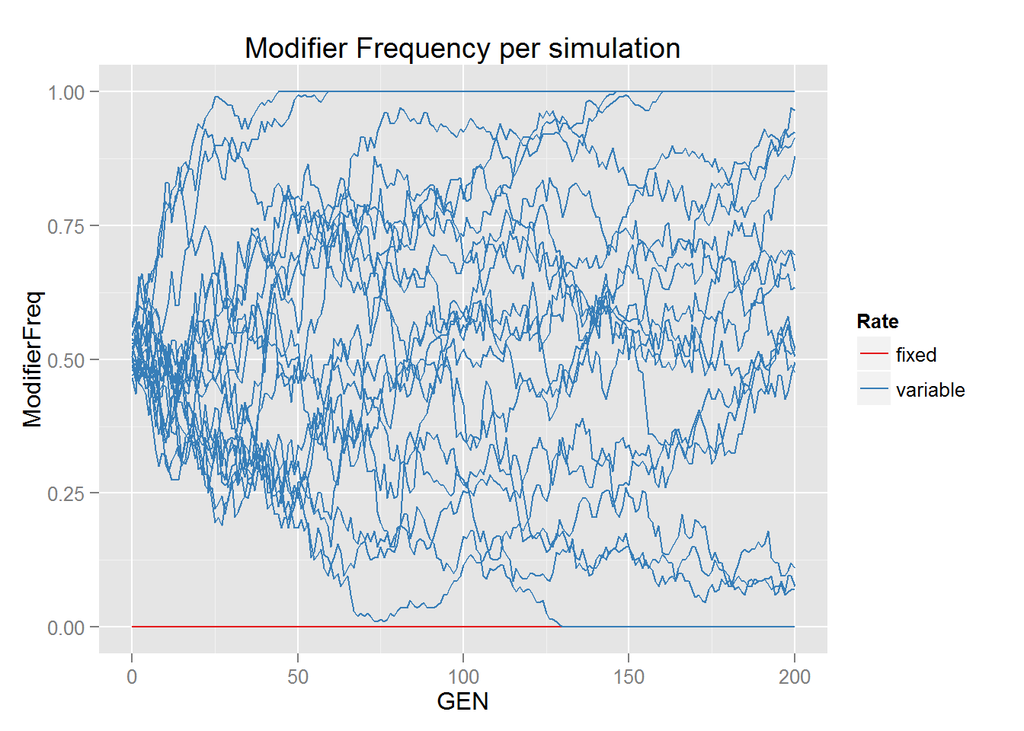

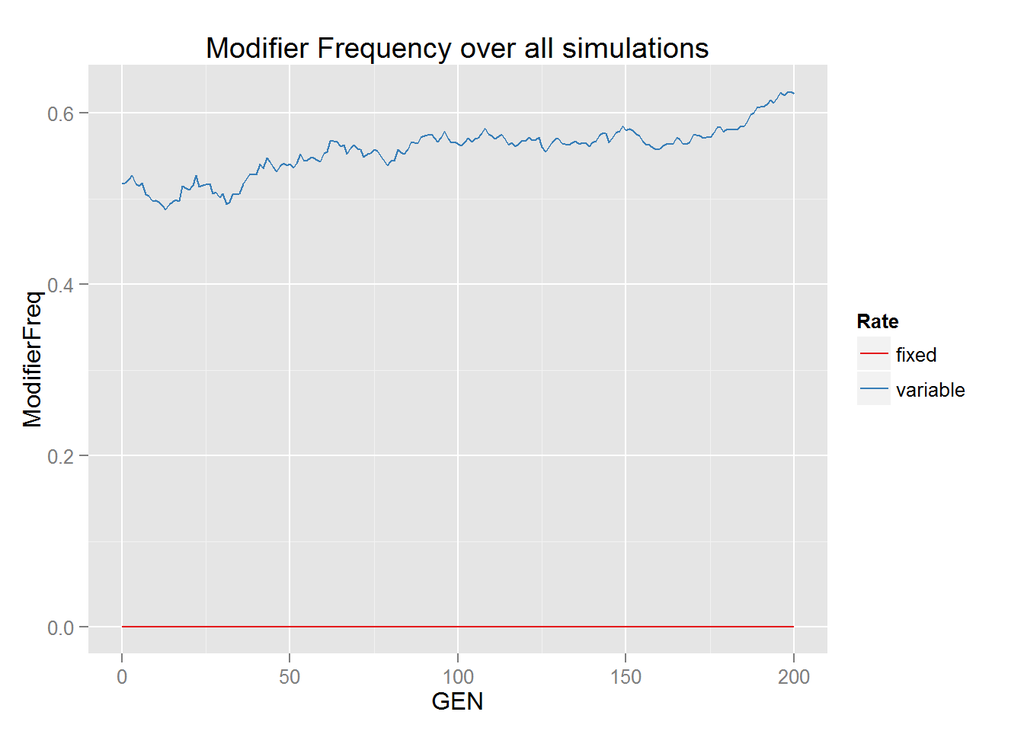